# Shift in American views on expenditures on dealing with drug addiction: Evidence from the GSS

## Setup

### Load packages

```r
Sys.setenv(TZ='United States')
library(ggplot2)
library(dplyr)
library(statsr)
```

### Load data

```r
load("gss.Rdata")
```

### Attach dataset (for variables easy access)

```r
attach(gss, warn.conflicts = FALSE)
```

## Part 1: Data

The [survey’s website](http://gss.norc.org/About-The-GSS) claims the *General Social Survey (GSS) is a nationally **representative survey of adults in the United States** conducted since 1972. The GSS collects data on contemporary American society in order to monitor and explain trends in opinions, attitudes and behaviors… The General Social Survey has carried out an extensive range of methodological research designed both to advance survey methods in general and to insure that the **GSS data are of the highest possible quality***.

#### Data Collection Method

Unlike the full General Social Survey Cumulative File, we are told in our course adjusted codebook that missing values were removed from the responses. Even though, there are still some missing values we would need to pay attention too when examining our research variables:

```r
NAs_cols <- colSums(is.na(gss))
NAs_cols
```

```
##   caseid     year      age      sex     race hispanic  uscitzn     educ
##        0        0      202        0        0    38141    56291      164
##   paeduc   maeduc   speduc   degree vetyears      sei  wrkstat   wrkslf
##    16888    10132    27435     1010    35177    25784       14     3512
##  marital spwrksta     sibs   childs agekdbrn  incom16     born  parborn
##       20    26364     1679      181    38942    13322     9257     9295
## granborn income06   coninc   region  partyid polviews    relig   attend
##    12065    46991     5829        0      327     9185      233     9969
##  natspac natenvir  natheal  natcity natcrime  natdrug  nateduc  natrace
##    25834    25447    24980    27965    25280    25646    24806    26752
##  natarms   nataid  natfare  natroad   natsoc  natmass  natpark confinan
##    25634    25555    25303    19566    19701    21427    19320    22008
##   conbus conclerg  coneduc   confed conlabor conpress conmedic    contv
##    19886    19699    18839    19424    20557    19122    18749    18912
## conjudge   consci conlegis  conarmy  joblose  jobfind   satjob richwork
##    19959    21290    19447    19414    38289    38389    15784    35113
##   jobinc   jobsec  jobhour jobpromo jobmeans    class     rank   satfin
##    36489    36487    36490    36491    36493     3425    47207     4607
## finalter  finrela    unemp   govaid   getaid    union getahead   parsol
##     4743     4946    21554    44976    55601    17683    22084    42234
##  kidssol abdefect abnomore   abhlth   abpoor   abrape absingle    abany
##    42464    17845    17968    17677    18033    18080    18041    25254
##   pillok  sexeduc   divlaw premarsx  teensex  xmarsex  homosex suicide1
##    36313    26381    24377    23513    35359    23042    24272    28235
## suicide2 suicide3 suicide4     fear   owngun   pistol  shotgun    rifle
##    27487    27557    27853    22766    22602    22842    22850    22850
##     news  tvhours  racdif1  racdif2  racdif3  racdif4 helppoor  helpnot
##    21372    23206    32975    32640    32602    33234    36895    37989
## helpsick  helpblk
##    37734    37177
```

The GSS [sampling design and weighting appendix](http://gss.norc.org/documents/codebook/GSS_Codebook_AppendixA.pdf) claims that *the sample was divided into two parts, one-half full probability and one-half **block** quota*, and that the **quota sampling is used with quotas based on sex, age, and employment status** - so we have a sufficient reason to believe the fourth principle of experimental design, **Blocking**, is fairly achieved for any variables we’ll examine. Even though, this study was not designed as an experimental one but rather **an observational**, so if we wish to find any causal relationship it would have to come from external factors, as done in [natural experiments](https://en.wikipedia.org/wiki/Natural_experiment).

```r
head(gss[0:8])
```

```
##   caseid year age    sex  race hispanic uscitzn educ
## 1      1 1972  23 Female White     <NA>    <NA>   16
## 2      2 1972  70   Male White     <NA>    <NA>   10
## 3      3 1972  48 Female White     <NA>    <NA>   12
## 4      4 1972  27 Female White     <NA>    <NA>   17
## 5      5 1972  61 Female White     <NA>    <NA>   12
## 6      6 1972  26   Male White     <NA>    <NA>   14
```

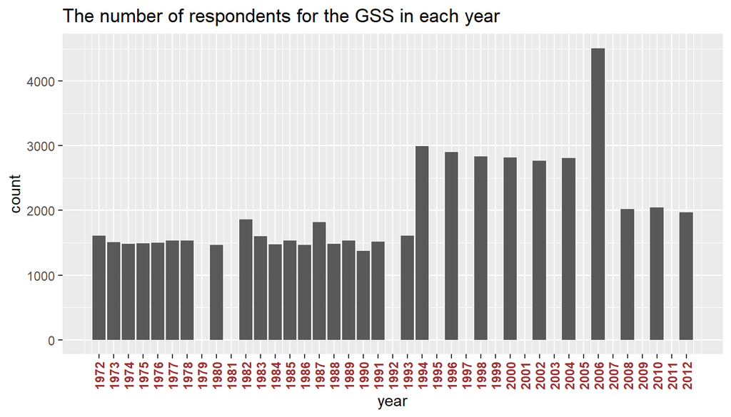

```r
ggplot(data = gss, aes(x = year)) +
    geom_bar() + ggtitle("The number of respondents for the GSS in each year") +
    theme(axis.text.x = element_text(face = "bold", color = "#993333", angle = 90, vjust = 0.5)) + scale_x_continuous(breaks=seq(1972, 2012, 1))
```

```r
respondents_years <- data.frame(table(year))
summary(respondents_years$Freq)
```

```
##    Min. 1st Qu.  Median    Mean 3rd Qu.    Max.
##    1372    1499    1599    1968    2044    4510
```

As we can see, we have data from 1972 to 2012, with some missing years. The number of respondents in each year varies from minimum of 1372 respondents in 1990 to maximum of 4510 respondents in 2006 - in any case we are told **we have a representative sample for each year, with more than 1300 observations without replacement but no more than 10% of the population** in of the entire US in each survey year (which in 1970 was 200M*10%=20M).

Our main reservation might be that there’s some non-neutrality in the way of asking the questions in the survey, or that people are answering the questions not truthfuly, and we’d have to address later on.

## Part 2: Research question

### Background - Changes in Marijuana abuse enforcment in the US over the recent years

In 1996, [California voters voted for California Proposition 215](https://www.myvetcandy.com/newsblog/2020/7/14/the-history-of-cbd), legalizing the growing and use of marijuana for medical purposes. On 6 November 2012, [Colorado and Washington state legalized possession of small amounts of marijuana](https://money.cnn.com/2012/11/07/news/economy/marijuana-legalization-washington-colorado/index.html) for private recreational use, and created a process for writing rules for legal growing and commercial distribution of marijuana within each state. In 2014-2019, [recreational use of marijuana was legislated](https://en.wikipedia.org/wiki/Drug_liberalization#United_States) in Oregon, Alaska, Washington D.C, California, Michigan and Illinois.

### Our variable of interest

**NATDRUG - DEALING WITH DRUG ADDICTION**

From the codebook: We are faced with many problems in this country, none of which can be solved easily or inexpensively. I’m going to name some of these problems, and for each one I’d like you to tell me **whether you think we’re spending too much money on it, too little money, or about the right amount for Dealing with drug addiction**:

1. TOO LITTLE
2. ABOUT RIGHT
3. TOO MUCH
4. NA - invalid response + don’t know + refused to answer

A reservation - the question might be phrased in a manner presenting the spending as a bad thing from the start, and people also might be affected by the answers and so might have an interest too lie.

In order to address that we’ll **assume the question has the exact same bias in different years asked, because the question has the same exact phrasing for all years and because the interest of the reposndants for answering the questions didn’t change on the course of the years**. While the first assumption sounds fairly correct, the second one might not be so - so we’ll keep this in mind when drawing conclusions from the inference.

### The research question

**Is the proportion of Americans who think ‘Too Much’ is spent on dealing with drug addiction different between 1994 and 2012?**

We used the proportion of *‘Too Much’* answers as our target value, and examined only two years of interest (1994 & 2012), in order to better define our research question. Almost all survies after 1993 had at least 2000 respondents, so we might give more credit to our results as representative of the population.

This questions is of interest to us, since it may reflect if the public is happy with the major drug enforcement reforms or their consequences that were done from 1996 onward. but we should always keep in mind - **we can’t say there’s any causal effect here**, first and foremost because it looks like there might be **simultaneous effects**: The changes in drug enforcement might effect the public opinion on dealing with drug addiction but also the public opinion might promote changes in drug enforcement.

Also, the dealing with drug addiction question is not exclusively related to Marijuana, and there might be **Confounding Factors** the affect the two subjects in matter, such as a growing spread of liberal ideals. This spread of liberal ideas might support both the lowering public expenditures in general (and drug addiction treatments expenditures in private) and the promotion of individualism and more self-responsibility of one on his own ‘mistakes’ (instead of helping him deal with his drug addiction).

## Part 3: Exploratory data analysis

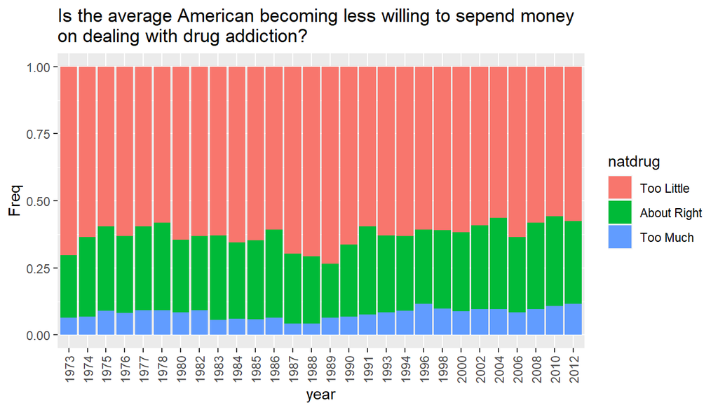

```r
attach(gss, warn.conflicts = FALSE)
natdrug_year_table <- table(year,natdrug)[2:29,]
#barplot(t(natdrug_year_table), las=2)
natdrug_year_prop_table <- prop.table(natdrug_year_table, margin=1)
ggplot(as.data.frame(natdrug_year_prop_table),aes(x=year,y=Freq, fill=natdrug)) + geom_col() + theme(axis.text.x = element_text(angle = 90, vjust = 0.5, hjust=1)) + ggtitle("Is the average American becoming less willing to sepend money \non dealing with drug addiction?")
```

The plot above shows the proportions of Americans in the survey (representative for the population as a whole) that believe ‘Too Little’, ‘About Right’ and ‘Too Much’ is spent on dealing with drug addiction. We can see that the ‘Too Much’ opinion is roughly increasing between 1994 and 2012, but we should zoom in a little to get a better perspective:

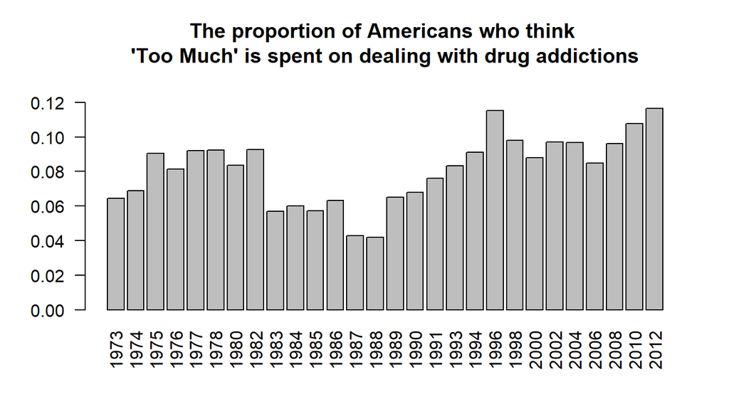

```r
hypothesis_table <- cbind(natdrug_year_prop_table[,1] + natdrug_year_prop_table[,2], natdrug_year_prop_table[,3])
df_hypothesis <- data.frame(cbind(natdrug_year_prop_table[,1] + natdrug_year_prop_table[,2], natdrug_year_prop_table[,3]))
colnames(df_hypothesis) <- c('Too little + About right','Too Much')
barplot(df_hypothesis$`Too Much`, names=rownames(df_hypothesis),las=2, ylim=c(0,0.13), main = "The proportion of Americans who think \n'Too Much' is spent on dealing with drug addictions")
```

```r
df_hypothesis[c("1994","2012"),]
```

```
##      Too little + About right  Too Much
## 1994                0.9088359 0.0911641
## 2012                0.8834746 0.1165254
```

```r
respondents_years %>% filter(year==1994 | year==2012)
```

```
##   year Freq
## 1 1994 2992
## 2 2012 1974
```

```r
data_natdrug_1994_2012 <- gss %>% select(c(natdrug,year)) %>% filter(year==1994|year==2012)
data_natdrug_1994_2012<- data.frame(data_natdrug_1994_2012)
data_natdrug_1994_2012<- data.frame(cbind(data_natdrug_1994_2012$natdrug=='Too Much',data_natdrug_1994_2012$year))
colnames(data_natdrug_1994_2012) <- c('too_much','year')
data_natdrug_1994_2012 <- data_natdrug_1994_2012[complete.cases(data_natdrug_1994_2012),]
data_natdrug_1994_2012[data_natdrug_1994_2012==1] <- "Yes"
data_natdrug_1994_2012[data_natdrug_1994_2012==0] <- "No"
table(data_natdrug_1994_2012)
```

```
##         year
## too_much 1994 2012
##      No  1296  834
##      Yes  130  110
```

We should now see if these results are statistically significant by their own and if those years are statistically different.

## Part 4: Inference

We’ll be **estimating the difference between two proportions** - the ‘Too Much’ proportion in 1994 and in 2012. First we’ll check the 95% confidence interval of the difference, and than we’ll perform hypothesis test. We don’t have to perform bootstrap since we can assume CLT and our sample size is big enough, but we’ll do it anyways to see if there’s any difference in the results.

### Confidence Interval

point estimate ± margin of error

#### Checking conditions

Conditions for inference for comparing two independent proportions:

1. Independence:

✓ within groups: sampled observations must be independent within each group.

`- The survey states the observations in years are independent.`

‣ random sample/assignment

`- We already checked that in the beginning of this analysis.`

‣ if sampling without replacement, n < 10% of population

✓ between groups: the two groups must be independent of each other (non-paired)

`- The survey states the observations between years are independent.`

2. Sample size/skew: Each sample should meet the success-failure condition:

✓ n1p1 ≥ 10 and n1(1-p1) ≥ 10

✓ n2p2 ≥ 10 and n2(1-p2) ≥ 10

Our observations might be right skewed since the proportions are very small and might be bound by zero, but we have surely enough observations.

–> We can assume that the sampling distribution of the difference between the two proportions is nearly normal.

#### Calculating the Confidence Interval

```r
inference(y = too_much, x=year, data = data_natdrug_1994_2012, statistic = "proportion", type = "ci", method = "theoretical", success = "Yes", order = c(2012,1994))
```

```
## Response variable: categorical (2 levels, success: Yes)
## Explanatory variable: categorical (2 levels)
## n_2012 = 944, p_hat_2012 = 0.1165
## n_1994 = 1426, p_hat_1994 = 0.0912
## 95% CI (2012 - 1994): (0 , 0.0507)
```

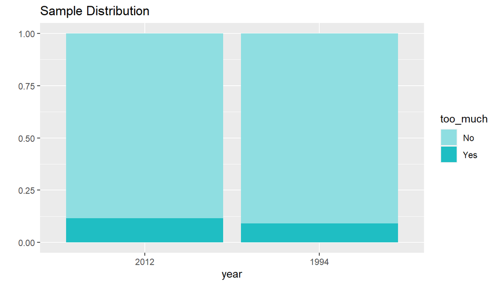

We are 95% confident the true difference in the proportion of people who believe we spend ‘Too Much’ on dealing with drug addiction between 2012 and 1994 is between 0 to 0.0507 (0-5.07%)

This means we are pretty sure there’s a significant difference between the public opinion in these two years. This difference means usually more people in 2012 think we spend Too Much, and the difference might range up to 5.07%, which is quite a lot when we look back at the proportion in `The proportion of American who think 'Too Much' is spend on dealing with drug addiction` barplot above. **But**, since 0 is inside our range, though in the edge, there’s also a slight chance the true difference between the years is 0, in this case there’s no difference at all in the opinion Americans in 1994 and 2012.

### Hypothesis Testing

Now we’ll perform a two sided hypothesis test, and in order to do that we’ll have to calculate the pooled proportion of ‘Too Much’.

p^pool = (130+110)/(1426+944) = 0.1013 = 10.13%

#### Checking conditions

We already checked independence in the confidence interval phase before.

2. Sample size/skew: Each sample should meet the success-failure condition:

✓ n1p^pool ≥ 10 and n1(1-p^pool) ≥ 10

✓ n2p^pool ≥ 10 and n2(1-p^pool) ≥ 10

–> We can assume that the sampling distribution of the difference between the two proportions is nearly normal.

#### Our Hypothesis

H0: p1 = p2, i.e. There’s no difference between the proportion of ‘Too Much’ in 1994 and in 2012. Ha: p1 != p2, i.e. There’s a significant difference between the proportion of ‘Too Much’ in 1994 and in 2012.

#### Hypothesis Testing

```r
inference(y = too_much, x=year, data = data_natdrug_1994_2012, statistic = "proportion", type = "ht", method = "theoretical", success = "Yes", order = c(2012,1994), alternative = "twosided", sig_level = 0.95)
```

```
## Response variable: categorical (2 levels, success: Yes)
## Explanatory variable: categorical (2 levels)
## n_2012 = 944, p_hat_2012 = 0.1165
## n_1994 = 1426, p_hat_1994 = 0.0912
## H0: p_2012 =  p_1994
## HA: p_2012 != p_1994
## z = 2.0035
## p_value = 0.0451
```

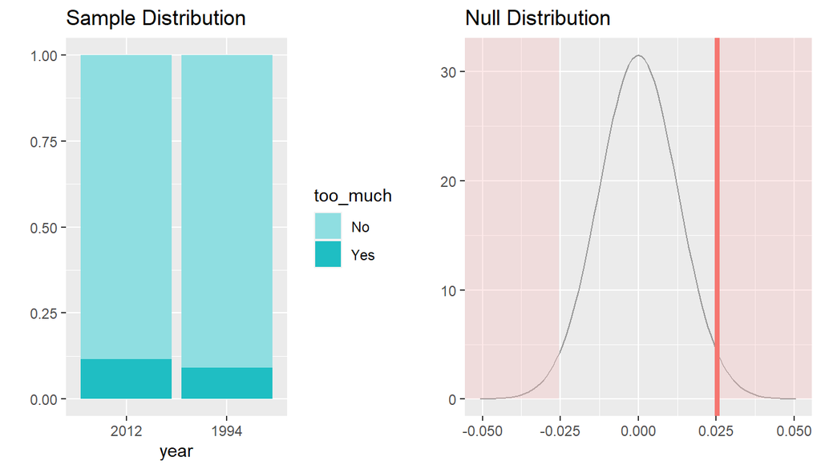

We can reject the null hypothesis with 95% confidence, meaning we are 95% confident the difference between ‘Too Much’ proportion in 2012 and 1994, which is 2.53%, is statistically significant. The p-value is actually 4.51%, so given there’s no difference between the 2012 and 1994 ‘Too Much’ propotions, the chance we would get a difference of 2.53% or greater or -2.53% or smaller is 4.51%, which is quite low (but not extremly low). So we can be pretty confident there is a significant difference between the public opinion on the matter in these two years, and we estimate that 2.53% more Americans in 2012 think we spend ‘Too Much’ on dealing with drug addiction.

### Bootstraping

We’ll now also try and simulate the results using bootstrap, just so we can see if there’s any difference (we don’t have to, as we have enough observations and we can assume CLT). We already checked the condition in the prior phases, and so we’ll get straight to the simulations (we’ll try both percentile and standard error methods):

```r
inference(y = too_much, x=year, data = data_natdrug_1994_2012, statistic = "proportion", type = "ht", method = "simulation", success = "Yes", order = c(2012,1994), alternative = "twosided", sig_level = 0.95, boot_method = "perc")
```

```
## Response variable: categorical (2 levels, success: Yes)
## Explanatory variable: categorical (2 levels)
## n_2012 = 944, p_hat_2012 = 0.1165
## n_1994 = 1426, p_hat_1994 = 0.0912
## H0: p_2012 =  p_1994
## HA: p_2012 != p_1994
## p_value = 0.0569
```

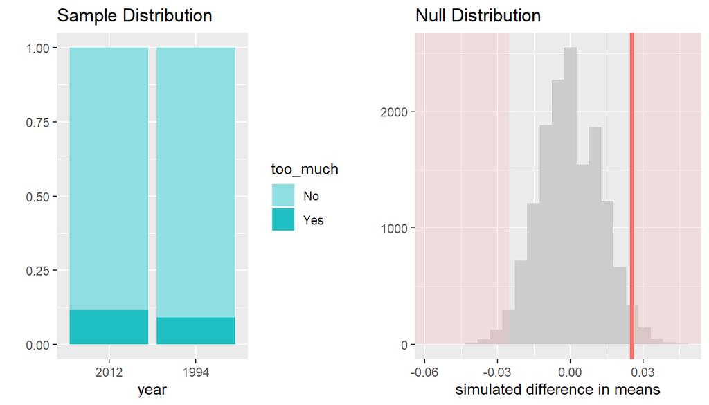

```r
inference(y = too_much, x=year, data = data_natdrug_1994_2012, statistic = "proportion", type = "ht", method = "simulation", success = "Yes", order = c(2012,1994), alternative = "twosided", sig_level = 0.95, boot_method = "se")
```

```
## Response variable: categorical (2 levels, success: Yes)
## Explanatory variable: categorical (2 levels)
## n_2012 = 944, p_hat_2012 = 0.1165
## n_1994 = 1426, p_hat_1994 = 0.0912
## H0: p_2012 =  p_1994
## HA: p_2012 != p_1994
## p_value = 0.0485
```

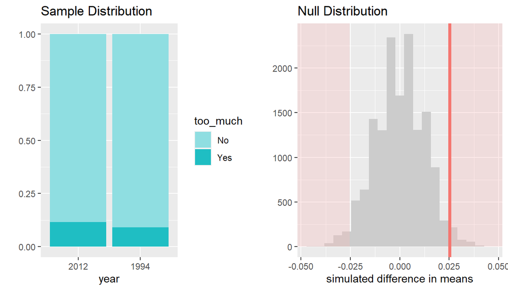

Our simulations suggest there’s either significant or not significant difference in proportions, which means we can’t safely reject using the 95% significance level the null hypothesis of a difference in the ‘Too Much’ proportions between the two years, but we should pay attention this is a really close call and it might change in any new simulation iteration…

## Conclusion and further research

We know the difference in proportions in our sample of Americans of thought we spend ‘Too Much’ on dealing with drug addiction between 2012 and 1994 is 2.53%. We are 95% confident the true difference in the population is between 0 and 5.07%. We also know that given an assumption that there’s no difference between the two years, our estimated sample proportion difference or a more extreme difference is 4.51% likely to occur, so we are 95% sure our result is significant. this is quite close to the minimum level of confidence, and the bootstrapping methods gave sometimes non-significant results because it is so close, but since our sample is big enough and we can assume CLT holds, and we will conclude the difference between the proportions of ‘Too Much’ in 2012 and 1994 is significant.

This results might open a doorway for more research on the satisfaction of people from the drug enforcement reforms, as people might be wanting to spend less of tax payer money on dealing with drug addiction.